# Risk Factor Analysis

## Outcome Variable

**Outcome Variable:** haz

## Predictor Variables

**Intervention Variable:** mbmi

**Adjustment Set:**

- arm
- W_mage
- meducyrs
- feducyrs
- hhwealth_quart
- brthmon
- W_parity
- impfloor
- impsan
- safeh20
- delta_W_mage
- delta_meducyrs
- delta_feducyrs
- delta_hhwealth_quart
- delta_brthmon
- delta_W_parity
- delta_impfloor
- delta_impsan
- delta_safeh20

## Stratifying Variables

The analysis was stratified on these variable(s):

- agecat
- studyid
- country

## Data Summary

| agecat | studyid | country | mbmi | n_cell | n | outcome_variable |
| --- | --- | --- | --- | --- | --- | --- |
| Birth | JiVitA-3 | BANGLADESH | Normal weight | 13720 | 22355 | haz |
| Birth | JiVitA-3 | BANGLADESH | Underweight | 8635 | 22355 | haz |
| Birth | MAL-ED | BANGLADESH | Normal weight | 194 | 222 | haz |
| Birth | MAL-ED | BANGLADESH | Underweight | 28 | 222 | haz |
| Birth | MAL-ED | BRAZIL | Normal weight | 59 | 64 | haz |
| Birth | MAL-ED | BRAZIL | Underweight | 5 | 64 | haz |
| Birth | MAL-ED | INDIA | Normal weight | 35 | 43 | haz |
| Birth | MAL-ED | INDIA | Underweight | 8 | 43 | haz |
| Birth | MAL-ED | NEPAL | Normal weight | 27 | 27 | haz |
| Birth | MAL-ED | NEPAL | Underweight | 0 | 27 | haz |
| Birth | MAL-ED | PERU | Normal weight | 221 | 226 | haz |
| Birth | MAL-ED | PERU | Underweight | 5 | 226 | haz |
| Birth | MAL-ED | SOUTH AFRICA | Normal weight | 98 | 101 | haz |
| Birth | MAL-ED | SOUTH AFRICA | Underweight | 3 | 101 | haz |
| Birth | MAL-ED | TANZANIA, UNITED REPUBLIC OF | Normal weight | 115 | 122 | haz |
| Birth | MAL-ED | TANZANIA, UNITED REPUBLIC OF | Underweight | 7 | 122 | haz |
| Birth | NIH-Birth | BANGLADESH | Normal weight | 506 | 608 | haz |
| Birth | NIH-Birth | BANGLADESH | Underweight | 102 | 608 | haz |
| Birth | NIH-Crypto | BANGLADESH | Normal weight | 663 | 729 | haz |
| Birth | NIH-Crypto | BANGLADESH | Underweight | 66 | 729 | haz |
| Birth | PROBIT | BELARUS | Normal weight | 13203 | 13726 | haz |
| Birth | PROBIT | BELARUS | Underweight | 523 | 13726 | haz |
| Birth | PROVIDE | BANGLADESH | Normal weight | 418 | 517 | haz |
| Birth | PROVIDE | BANGLADESH | Underweight | 99 | 517 | haz |
| Birth | SAS-CompFeed | INDIA | Normal weight | 830 | 1135 | haz |
| Birth | SAS-CompFeed | INDIA | Underweight | 305 | 1135 | haz |
| Birth | ZVITAMBO | ZIMBABWE | Normal weight | 9162 | 9672 | haz |
| Birth | ZVITAMBO | ZIMBABWE | Underweight | 510 | 9672 | haz |
| 6 months | JiVitA-3 | BANGLADESH | Normal weight | 10311 | 16760 | haz |
| 6 months | JiVitA-3 | BANGLADESH | Underweight | 6449 | 16760 | haz |

[output cut: 60 more lines]

The following strata were considered:

- agecat: 24 months, studyid: JiVitA-3, country: BANGLADESH
- agecat: 24 months, studyid: LCNI-5, country: MALAWI
- agecat: 24 months, studyid: MAL-ED, country: BANGLADESH
- agecat: 24 months, studyid: MAL-ED, country: BRAZIL
- agecat: 24 months, studyid: MAL-ED, country: INDIA
- agecat: 24 months, studyid: MAL-ED, country: NEPAL
- agecat: 24 months, studyid: MAL-ED, country: PERU
- agecat: 24 months, studyid: MAL-ED, country: SOUTH AFRICA
- agecat: 24 months, studyid: MAL-ED, country: TANZANIA, UNITED REPUBLIC OF
- agecat: 24 months, studyid: NIH-Birth, country: BANGLADESH
- agecat: 24 months, studyid: NIH-Crypto, country: BANGLADESH
- agecat: 24 months, studyid: PROBIT, country: BELARUS
- agecat: 24 months, studyid: PROVIDE, country: BANGLADESH
- agecat: 24 months, studyid: TanzaniaChild2, country: TANZANIA, UNITED REPUBLIC OF
- agecat: 24 months, studyid: ZVITAMBO, country: ZIMBABWE
- agecat: 6 months, studyid: JiVitA-3, country: BANGLADESH
- agecat: 6 months, studyid: LCNI-5, country: MALAWI
- agecat: 6 months, studyid: MAL-ED, country: BANGLADESH
- agecat: 6 months, studyid: MAL-ED, country: BRAZIL
- agecat: 6 months, studyid: MAL-ED, country: INDIA
- agecat: 6 months, studyid: MAL-ED, country: NEPAL
- agecat: 6 months, studyid: MAL-ED, country: PERU
- agecat: 6 months, studyid: MAL-ED, country: SOUTH AFRICA
- agecat: 6 months, studyid: MAL-ED, country: TANZANIA, UNITED REPUBLIC OF
- agecat: 6 months, studyid: NIH-Birth, country: BANGLADESH
- agecat: 6 months, studyid: NIH-Crypto, country: BANGLADESH
- agecat: 6 months, studyid: PROBIT, country: BELARUS
- agecat: 6 months, studyid: PROVIDE, country: BANGLADESH
- agecat: 6 months, studyid: SAS-CompFeed, country: INDIA
- agecat: 6 months, studyid: TanzaniaChild2, country: TANZANIA, UNITED REPUBLIC OF
- agecat: 6 months, studyid: ZVITAMBO, country: ZIMBABWE
- agecat: Birth, studyid: JiVitA-3, country: BANGLADESH
- agecat: Birth, studyid: MAL-ED, country: BANGLADESH
- agecat: Birth, studyid: MAL-ED, country: BRAZIL
- agecat: Birth, studyid: MAL-ED, country: INDIA
- agecat: Birth, studyid: MAL-ED, country: NEPAL
- agecat: Birth, studyid: MAL-ED, country: PERU
- agecat: Birth, studyid: MAL-ED, country: SOUTH AFRICA
- agecat: Birth, studyid: MAL-ED, country: TANZANIA, UNITED REPUBLIC OF
- agecat: Birth, studyid: NIH-Birth, country: BANGLADESH
- agecat: Birth, studyid: NIH-Crypto, country: BANGLADESH
- agecat: Birth, studyid: PROBIT, country: BELARUS
- agecat: Birth, studyid: PROVIDE, country: BANGLADESH
- agecat: Birth, studyid: SAS-CompFeed, country: INDIA
- agecat: Birth, studyid: ZVITAMBO, country: ZIMBABWE

### Dropped Strata

Some strata were dropped due to rare outcomes:

- agecat: Birth, studyid: MAL-ED, country: NEPAL
- agecat: Birth, studyid: MAL-ED, country: SOUTH AFRICA
- agecat: 6 months, studyid: MAL-ED, country: NEPAL
- agecat: 24 months, studyid: MAL-ED, country: NEPAL
- agecat: 24 months, studyid: MAL-ED, country: PERU
- agecat: 24 months, studyid: TanzaniaChild2, country: TANZANIA, UNITED REPUBLIC OF

## Methods Detail

We’re interested in the causal parameters $E[Y_a]$ for all values of $a \in \mathcal{A}$. These parameters represent the mean outcome if, possibly contrary to fact, we intervened to set all units to have $A=a$. Under the randomization and positivity assumptions, these are identified by the statistical parameters $\psi_a=E_W[E_{Y|A,W}(Y|A=a,W)]$. In addition, we’re interested in the mean of $Y$, $E[Y]$ under no intervention (the observed mean). We will estimate these parameters by using SuperLearner to fit the relevant likelihood factors – $E_{Y|A,W}(Y|A=a,W)$ and $p(A=a|W)$, and then updating our likelihood fit using a joint TMLE.

For unadjusted analyses ($W=\{\}$), initial likelihoods were estimated using Lrnr_glm to estimate the simple $E(Y|A)$ and Lrnr_mean to estimate $p(A)$. For adjusted analyses, a small library containing Lrnr_glmnet, Lrnr_xgboost, and Lrnr_mean was used.

Having estimated these parameters, we will then use the delta method to estimate relative risks and attributable risks relative to a prespecified baseline level of $A$.

# Results Detail

## Results Plots

[figure not shown]

[figure not shown]

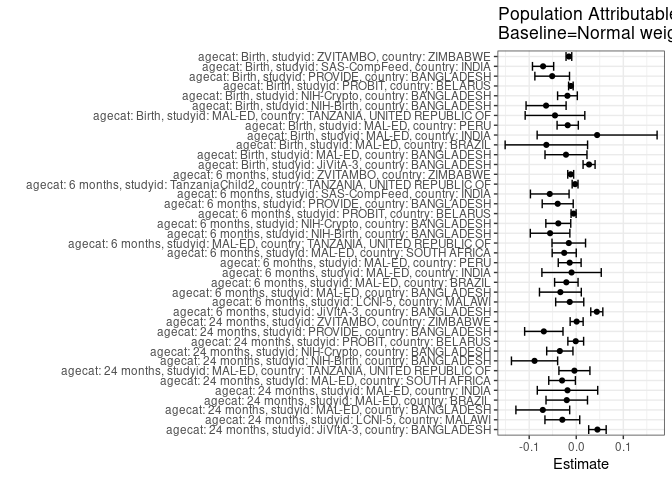

## Results Table

### Parameter: TSM

| agecat | studyid | country | intervention_level | baseline_level | estimate | ci_lower | ci_upper |
| --- | --- | --- | --- | --- | --- | --- | --- |
| Birth | JiVitA-3 | BANGLADESH | Normal weight | NA | -1.6165624 | -1.6397188 | -1.5934060 |
| Birth | JiVitA-3 | BANGLADESH | Underweight | NA | -1.5460985 | -1.5743973 | -1.5177998 |
| Birth | MAL-ED | BANGLADESH | Normal weight | NA | -1.0560733 | -1.2028232 | -0.9093234 |
| Birth | MAL-ED | BANGLADESH | Underweight | NA | -1.1933572 | -1.5209343 | -0.8657801 |
| Birth | MAL-ED | BRAZIL | Normal weight | NA | -0.6249153 | -0.9137560 | -0.3360745 |
| Birth | MAL-ED | BRAZIL | Underweight | NA | -1.4380000 | -2.2732876 | -0.6027124 |
| Birth | MAL-ED | INDIA | Normal weight | NA | -1.2745714 | -1.6299983 | -0.9191446 |
| Birth | MAL-ED | INDIA | Underweight | NA | -1.0362500 | -1.6020040 | -0.4704960 |
| Birth | MAL-ED | PERU | Normal weight | NA | -0.8869683 | -1.0065725 | -0.7673641 |
| Birth | MAL-ED | PERU | Underweight | NA | -1.7080000 | -2.3409322 | -1.0750678 |
| Birth | MAL-ED | TANZANIA, UNITED REPUBLIC OF | Normal weight | NA | -1.0913043 | -1.3056634 | -0.8769453 |
| Birth | MAL-ED | TANZANIA, UNITED REPUBLIC OF | Underweight | NA | -1.8785714 | -2.8008825 | -0.9562603 |
| Birth | NIH-Birth | BANGLADESH | Normal weight | NA | -0.8669099 | -0.9623766 | -0.7714431 |
| Birth | NIH-Birth | BANGLADESH | Underweight | NA | -1.2092137 | -1.4398780 | -0.9785495 |
| Birth | NIH-Crypto | BANGLADESH | Normal weight | NA | -0.8902288 | -0.9664433 | -0.8140143 |
| Birth | NIH-Crypto | BANGLADESH | Underweight | NA | -1.1073059 | -1.3255840 | -0.8890278 |
| Birth | PROBIT | BELARUS | Normal weight | NA | 1.3232747 | 1.1631267 | 1.4834228 |
| Birth | PROBIT | BELARUS | Underweight | NA | 0.9690618 | 0.7745284 | 1.1635953 |
| Birth | PROVIDE | BANGLADESH | Normal weight | NA | -0.8413859 | -0.9266412 | -0.7561307 |
| Birth | PROVIDE | BANGLADESH | Underweight | NA | -1.1288386 | -1.3017096 | -0.9559676 |
| Birth | SAS-CompFeed | INDIA | Normal weight | NA | -1.3733276 | -1.4687330 | -1.2779222 |
| Birth | SAS-CompFeed | INDIA | Underweight | NA | -1.6367608 | -1.7433420 | -1.5301795 |
| Birth | ZVITAMBO | ZIMBABWE | Normal weight | NA | -0.4608098 | -0.4858737 | -0.4357459 |
| Birth | ZVITAMBO | ZIMBABWE | Underweight | NA | -0.7775873 | -0.8974500 | -0.6577245 |
| 6 months | JiVitA-3 | BANGLADESH | Normal weight | NA | -1.3576537 | -1.3845029 | -1.3308045 |
| 6 months | JiVitA-3 | BANGLADESH | Underweight | NA | -1.2454361 | -1.2760266 | -1.2148455 |
| 6 months | LCNI-5 | MALAWI | Normal weight | NA | -1.6438897 | -1.7219978 | -1.5657817 |
| 6 months | LCNI-5 | MALAWI | Underweight | NA | -1.7182564 | -1.8785336 | -1.5579793 |
| 6 months | MAL-ED | BANGLADESH | Normal weight | NA | -1.1712660 | -1.2961242 | -1.0464078 |
| 6 months | MAL-ED | BANGLADESH | Underweight | NA | -1.4296244 | -1.7278456 | -1.1314033 |
| 6 months | MAL-ED | BRAZIL | Normal weight | NA | 0.0708375 | -0.0781476 | 0.2198227 |
| 6 months | MAL-ED | BRAZIL | Underweight | NA | -0.4164815 | -0.8769172 | 0.0439543 |
| 6 months | MAL-ED | INDIA | Normal weight | NA | -1.1960102 | -1.3306032 | -1.0614172 |
| 6 months | MAL-ED | INDIA | Underweight | NA | -1.2156122 | -1.4987278 | -0.9324967 |
| 6 months | MAL-ED | PERU | Normal weight | NA | -1.3101467 | -1.4185443 | -1.2017491 |
| 6 months | MAL-ED | PERU | Underweight | NA | -2.0693333 | -2.9031517 | -1.2355150 |
| 6 months | MAL-ED | SOUTH AFRICA | Normal weight | NA | -1.0471625 | -1.1780920 | -0.9162331 |
| 6 months | MAL-ED | SOUTH AFRICA | Underweight | NA | -1.9571429 | -2.5636947 | -1.3505910 |
| 6 months | MAL-ED | TANZANIA, UNITED REPUBLIC OF | Normal weight | NA | -1.3528774 | -1.4769494 | -1.2288053 |
| 6 months | MAL-ED | TANZANIA, UNITED REPUBLIC OF | Underweight | NA | -1.5939309 | -2.2378404 | -0.9500214 |
| 6 months | NIH-Birth | BANGLADESH | Normal weight | NA | -1.3517878 | -1.4469199 | -1.2566556 |
| 6 months | NIH-Birth | BANGLADESH | Underweight | NA | -1.6331896 | -1.8718904 | -1.3944889 |
| 6 months | NIH-Crypto | BANGLADESH | Normal weight | NA | -1.1605198 | -1.2345263 | -1.0865133 |
| 6 months | NIH-Crypto | BANGLADESH | Underweight | NA | -1.5982207 | -1.8536252 | -1.3428162 |
| 6 months | PROBIT | BELARUS | Normal weight | NA | 0.1132753 | 0.0234172 | 0.2031333 |
| 6 months | PROBIT | BELARUS | Underweight | NA | -0.0233026 | -0.2045491 | 0.1579439 |
| 6 months | PROVIDE | BANGLADESH | Normal weight | NA | -1.0501244 | -1.1325533 | -0.9676956 |
| 6 months | PROVIDE | BANGLADESH | Underweight | NA | -1.3136082 | -1.4926921 | -1.1345243 |
| 6 months | SAS-CompFeed | INDIA | Normal weight | NA | -1.3505682 | -1.4534104 | -1.2477259 |
| 6 months | SAS-CompFeed | INDIA | Underweight | NA | -1.5790690 | -1.7226816 | -1.4354564 |
| 6 months | TanzaniaChild2 | TANZANIA, UNITED REPUBLIC OF | Normal weight | NA | -0.5380893 | -0.5883836 | -0.4877950 |
| 6 months | TanzaniaChild2 | TANZANIA, UNITED REPUBLIC OF | Underweight | NA | -0.7098291 | -0.9728848 | -0.4467735 |
| 6 months | ZVITAMBO | ZIMBABWE | Normal weight | NA | -0.8682481 | -0.8964307 | -0.8400655 |
| 6 months | ZVITAMBO | ZIMBABWE | Underweight | NA | -1.1112050 | -1.2357514 | -0.9866586 |
| 24 months | JiVitA-3 | BANGLADESH | Normal weight | NA | -2.0587574 | -2.0925692 | -2.0249455 |
| 24 months | JiVitA-3 | BANGLADESH | Underweight | NA | -1.9420547 | -1.9818163 | -1.9022931 |
| 24 months | LCNI-5 | MALAWI | Normal weight | NA | -1.8556076 | -1.9442329 | -1.7669823 |
| 24 months | LCNI-5 | MALAWI | Underweight | NA | -1.9444000 | -2.1517833 | -1.7370167 |
| 24 months | MAL-ED | BANGLADESH | Normal weight | NA | -1.9073099 | -2.0387174 | -1.7759025 |
| 24 months | MAL-ED | BANGLADESH | Underweight | NA | -2.4211607 | -2.7927166 | -2.0496048 |
| 24 months | MAL-ED | BRAZIL | Normal weight | NA | 0.0261008 | -0.1439691 | 0.1961708 |
| 24 months | MAL-ED | BRAZIL | Underweight | NA | -0.5391667 | -1.6773310 | 0.5989977 |
| 24 months | MAL-ED | INDIA | Normal weight | NA | -1.8658809 | -2.0068279 | -1.7249338 |
| 24 months | MAL-ED | INDIA | Underweight | NA | -1.8578180 | -2.1321364 | -1.5834995 |
| 24 months | MAL-ED | SOUTH AFRICA | Normal weight | NA | -1.6131241 | -1.7506877 | -1.4755605 |
| 24 months | MAL-ED | SOUTH AFRICA | Underweight | NA | -2.6192857 | -3.1998173 | -2.0387542 |
| 24 months | MAL-ED | TANZANIA, UNITED REPUBLIC OF | Normal weight | NA | -2.6416623 | -2.7803408 | -2.5029838 |
| 24 months | MAL-ED | TANZANIA, UNITED REPUBLIC OF | Underweight | NA | -2.7391023 | -3.4056583 | -2.0725464 |
| 24 months | NIH-Birth | BANGLADESH | Normal weight | NA | -2.1304295 | -2.2432625 | -2.0175966 |
| 24 months | NIH-Birth | BANGLADESH | Underweight | NA | -2.5924949 | -2.8187580 | -2.3662319 |
| 24 months | NIH-Crypto | BANGLADESH | Normal weight | NA | -1.4063556 | -1.4929716 | -1.3197397 |
| 24 months | NIH-Crypto | BANGLADESH | Underweight | NA | -1.8311480 | -2.1442009 | -1.5180950 |
| 24 months | PROBIT | BELARUS | Normal weight | NA | -0.1433200 | -0.4293742 | 0.1427341 |
| 24 months | PROBIT | BELARUS | Underweight | NA | -0.1952021 | -0.6769714 | 0.2865673 |
| 24 months | PROVIDE | BANGLADESH | Normal weight | NA | -1.5313492 | -1.6208810 | -1.4418174 |
| 24 months | PROVIDE | BANGLADESH | Underweight | NA | -2.0046954 | -2.2320896 | -1.7773013 |
| 24 months | ZVITAMBO | ZIMBABWE | Normal weight | NA | -1.5991465 | -1.6627238 | -1.5355692 |
| 24 months | ZVITAMBO | ZIMBABWE | Underweight | NA | -1.6726438 | -1.9874541 | -1.3578334 |

### Parameter: E(Y)

| agecat | studyid | country | intervention_level | baseline_level | estimate | ci_lower | ci_upper |
| --- | --- | --- | --- | --- | --- | --- | --- |
| Birth | JiVitA-3 | BANGLADESH | NA | NA | -1.5893196 | -1.6086080 | -1.5700313 |
| Birth | MAL-ED | BANGLADESH | NA | NA | -1.0778829 | -1.2122580 | -0.9435077 |
| Birth | MAL-ED | BRAZIL | NA | NA | -0.6884375 | -0.9678371 | -0.4090379 |
| Birth | MAL-ED | INDIA | NA | NA | -1.2302326 | -1.5393614 | -0.9211037 |
| Birth | MAL-ED | PERU | NA | NA | -0.9051327 | -1.0238686 | -0.7863969 |
| Birth | MAL-ED | TANZANIA, UNITED REPUBLIC OF | NA | NA | -1.1364754 | -1.3478823 | -0.9250686 |
| Birth | NIH-Birth | BANGLADESH | NA | NA | -0.9310197 | -1.0197391 | -0.8423003 |
| Birth | NIH-Crypto | BANGLADESH | NA | NA | -0.9089163 | -0.9806324 | -0.8372002 |
| Birth | PROBIT | BELARUS | NA | NA | 1.3118585 | 1.1523374 | 1.4713797 |
| Birth | PROVIDE | BANGLADESH | NA | NA | -0.8925145 | -0.9687201 | -0.8163089 |
| Birth | SAS-CompFeed | INDIA | NA | NA | -1.4438150 | -1.5337502 | -1.3538797 |
| Birth | ZVITAMBO | ZIMBABWE | NA | NA | -0.4764413 | -0.5009156 | -0.4519670 |
| 6 months | JiVitA-3 | BANGLADESH | NA | NA | -1.3140048 | -1.3371141 | -1.2908955 |
| 6 months | LCNI-5 | MALAWI | NA | NA | -1.6577751 | -1.7275296 | -1.5880207 |
| 6 months | MAL-ED | BANGLADESH | NA | NA | -1.2049931 | -1.3222136 | -1.0877726 |
| 6 months | MAL-ED | BRAZIL | NA | NA | 0.0497516 | -0.0948051 | 0.1943083 |
| 6 months | MAL-ED | INDIA | NA | NA | -1.2059574 | -1.3243030 | -1.0876119 |
| 6 months | MAL-ED | PERU | NA | NA | -1.3241023 | -1.4325083 | -1.2156964 |
| 6 months | MAL-ED | SOUTH AFRICA | NA | NA | -1.0727443 | -1.2024880 | -0.9430006 |
| 6 months | MAL-ED | TANZANIA, UNITED REPUBLIC OF | NA | NA | -1.3687449 | -1.4907629 | -1.2467270 |
| 6 months | NIH-Birth | BANGLADESH | NA | NA | -1.4073821 | -1.4960598 | -1.3187043 |
| 6 months | NIH-Crypto | BANGLADESH | NA | NA | -1.1986783 | -1.2700937 | -1.1272630 |
| 6 months | PROBIT | BELARUS | NA | NA | 0.1076224 | 0.0168411 | 0.1984037 |
| 6 months | PROVIDE | BANGLADESH | NA | NA | -1.0895301 | -1.1639589 | -1.0151013 |
| 6 months | SAS-CompFeed | INDIA | NA | NA | -1.4068893 | -1.4981242 | -1.3156543 |
| 6 months | TanzaniaChild2 | TANZANIA, UNITED REPUBLIC OF | NA | NA | -0.5405711 | -0.5899965 | -0.4911457 |
| 6 months | ZVITAMBO | ZIMBABWE | NA | NA | -0.8800508 | -0.9074511 | -0.8526506 |
| 24 months | JiVitA-3 | BANGLADESH | NA | NA | -2.0137632 | -2.0415122 | -1.9860142 |
| 24 months | LCNI-5 | MALAWI | NA | NA | -1.8851820 | -1.9664818 | -1.8038822 |
| 24 months | MAL-ED | BANGLADESH | NA | NA | -1.9783962 | -2.1050210 | -1.8517715 |
| 24 months | MAL-ED | BRAZIL | NA | NA | 0.0059127 | -0.1637934 | 0.1756188 |
| 24 months | MAL-ED | INDIA | NA | NA | -1.8844690 | -2.0097879 | -1.7591502 |
| 24 months | MAL-ED | SOUTH AFRICA | NA | NA | -1.6432229 | -1.7795844 | -1.5068615 |
| 24 months | MAL-ED | TANZANIA, UNITED REPUBLIC OF | NA | NA | -2.6455607 | -2.7807256 | -2.5103959 |
| 24 months | NIH-Birth | BANGLADESH | NA | NA | -2.2190579 | -2.3217459 | -2.1163699 |
| 24 months | NIH-Crypto | BANGLADESH | NA | NA | -1.4412646 | -1.5249156 | -1.3576135 |
| 24 months | PROBIT | BELARUS | NA | NA | -0.1444149 | -0.4258602 | 0.1370304 |
| 24 months | PROVIDE | BANGLADESH | NA | NA | -1.6002600 | -1.6836163 | -1.5169036 |
| 24 months | ZVITAMBO | ZIMBABWE | NA | NA | -1.5983212 | -1.6605141 | -1.5361283 |

### Parameter: ATE

| agecat | studyid | country | intervention_level | baseline_level | estimate | ci_lower | ci_upper |
| --- | --- | --- | --- | --- | --- | --- | --- |
| Birth | JiVitA-3 | BANGLADESH | Normal weight | Normal weight | 0.0000000 | 0.0000000 | 0.0000000 |
| Birth | JiVitA-3 | BANGLADESH | Underweight | Normal weight | 0.0704638 | 0.0372563 | 0.1036714 |
| Birth | MAL-ED | BANGLADESH | Normal weight | Normal weight | 0.0000000 | 0.0000000 | 0.0000000 |
| Birth | MAL-ED | BANGLADESH | Underweight | Normal weight | -0.1372839 | -0.4968358 | 0.2222680 |
| Birth | MAL-ED | BRAZIL | Normal weight | Normal weight | 0.0000000 | 0.0000000 | 0.0000000 |
| Birth | MAL-ED | BRAZIL | Underweight | Normal weight | -0.8130847 | -1.6969028 | 0.0707333 |
| Birth | MAL-ED | INDIA | Normal weight | Normal weight | 0.0000000 | 0.0000000 | 0.0000000 |
| Birth | MAL-ED | INDIA | Underweight | Normal weight | 0.2383214 | -0.4298147 | 0.9064576 |
| Birth | MAL-ED | PERU | Normal weight | Normal weight | 0.0000000 | 0.0000000 | 0.0000000 |
| Birth | MAL-ED | PERU | Underweight | Normal weight | -0.8210317 | -1.4651655 | -0.1768979 |
| Birth | MAL-ED | TANZANIA, UNITED REPUBLIC OF | Normal weight | Normal weight | 0.0000000 | 0.0000000 | 0.0000000 |
| Birth | MAL-ED | TANZANIA, UNITED REPUBLIC OF | Underweight | Normal weight | -0.7872671 | -1.7341607 | 0.1596266 |
| Birth | NIH-Birth | BANGLADESH | Normal weight | Normal weight | 0.0000000 | 0.0000000 | 0.0000000 |
| Birth | NIH-Birth | BANGLADESH | Underweight | Normal weight | -0.3423039 | -0.5922006 | -0.0924072 |
| Birth | NIH-Crypto | BANGLADESH | Normal weight | Normal weight | 0.0000000 | 0.0000000 | 0.0000000 |
| Birth | NIH-Crypto | BANGLADESH | Underweight | Normal weight | -0.2170771 | -0.4474053 | 0.0132510 |
| Birth | PROBIT | BELARUS | Normal weight | Normal weight | 0.0000000 | 0.0000000 | 0.0000000 |
| Birth | PROBIT | BELARUS | Underweight | Normal weight | -0.3542129 | -0.4925365 | -0.2158893 |
| Birth | PROVIDE | BANGLADESH | Normal weight | Normal weight | 0.0000000 | 0.0000000 | 0.0000000 |
| Birth | PROVIDE | BANGLADESH | Underweight | Normal weight | -0.2874527 | -0.4804928 | -0.0944125 |
| Birth | SAS-CompFeed | INDIA | Normal weight | Normal weight | 0.0000000 | 0.0000000 | 0.0000000 |
| Birth | SAS-CompFeed | INDIA | Underweight | Normal weight | -0.2634332 | -0.3385645 | -0.1883018 |
| Birth | ZVITAMBO | ZIMBABWE | Normal weight | Normal weight | 0.0000000 | 0.0000000 | 0.0000000 |
| Birth | ZVITAMBO | ZIMBABWE | Underweight | Normal weight | -0.3167774 | -0.4391873 | -0.1943676 |
| 6 months | JiVitA-3 | BANGLADESH | Normal weight | Normal weight | 0.0000000 | 0.0000000 | 0.0000000 |
| 6 months | JiVitA-3 | BANGLADESH | Underweight | Normal weight | 0.1122176 | 0.0787576 | 0.1456777 |
| 6 months | LCNI-5 | MALAWI | Normal weight | Normal weight | 0.0000000 | 0.0000000 | 0.0000000 |
| 6 months | LCNI-5 | MALAWI | Underweight | Normal weight | -0.0743667 | -0.2528064 | 0.1040730 |
| 6 months | MAL-ED | BANGLADESH | Normal weight | Normal weight | 0.0000000 | 0.0000000 | 0.0000000 |
| 6 months | MAL-ED | BANGLADESH | Underweight | Normal weight | -0.2583584 | -0.5811148 | 0.0643979 |
| 6 months | MAL-ED | BRAZIL | Normal weight | Normal weight | 0.0000000 | 0.0000000 | 0.0000000 |
| 6 months | MAL-ED | BRAZIL | Underweight | Normal weight | -0.4873190 | -0.9712587 | -0.0033793 |
| 6 months | MAL-ED | INDIA | Normal weight | Normal weight | 0.0000000 | 0.0000000 | 0.0000000 |
| 6 months | MAL-ED | INDIA | Underweight | Normal weight | -0.0196020 | -0.3342579 | 0.2950540 |
| 6 months | MAL-ED | PERU | Normal weight | Normal weight | 0.0000000 | 0.0000000 | 0.0000000 |
| 6 months | MAL-ED | PERU | Underweight | Normal weight | -0.7591866 | -1.6000214 | 0.0816481 |
| 6 months | MAL-ED | SOUTH AFRICA | Normal weight | Normal weight | 0.0000000 | 0.0000000 | 0.0000000 |
| 6 months | MAL-ED | SOUTH AFRICA | Underweight | Normal weight | -0.9099803 | -1.5305024 | -0.2894583 |
| 6 months | MAL-ED | TANZANIA, UNITED REPUBLIC OF | Normal weight | Normal weight | 0.0000000 | 0.0000000 | 0.0000000 |
| 6 months | MAL-ED | TANZANIA, UNITED REPUBLIC OF | Underweight | Normal weight | -0.2410535 | -0.8970403 | 0.4149332 |
| 6 months | NIH-Birth | BANGLADESH | Normal weight | Normal weight | 0.0000000 | 0.0000000 | 0.0000000 |
| 6 months | NIH-Birth | BANGLADESH | Underweight | Normal weight | -0.2814019 | -0.5362122 | -0.0265915 |
| 6 months | NIH-Crypto | BANGLADESH | Normal weight | Normal weight | 0.0000000 | 0.0000000 | 0.0000000 |
| 6 months | NIH-Crypto | BANGLADESH | Underweight | Normal weight | -0.4377009 | -0.7038202 | -0.1715815 |
| 6 months | PROBIT | BELARUS | Normal weight | Normal weight | 0.0000000 | 0.0000000 | 0.0000000 |
| 6 months | PROBIT | BELARUS | Underweight | Normal weight | -0.1365779 | -0.2744492 | 0.0012934 |
| 6 months | PROVIDE | BANGLADESH | Normal weight | Normal weight | 0.0000000 | 0.0000000 | 0.0000000 |
| 6 months | PROVIDE | BANGLADESH | Underweight | Normal weight | -0.2634838 | -0.4608433 | -0.0661242 |
| 6 months | SAS-CompFeed | INDIA | Normal weight | Normal weight | 0.0000000 | 0.0000000 | 0.0000000 |
| 6 months | SAS-CompFeed | INDIA | Underweight | Normal weight | -0.2285009 | -0.3848254 | -0.0721763 |
| 6 months | TanzaniaChild2 | TANZANIA, UNITED REPUBLIC OF | Normal weight | Normal weight | 0.0000000 | 0.0000000 | 0.0000000 |
| 6 months | TanzaniaChild2 | TANZANIA, UNITED REPUBLIC OF | Underweight | Normal weight | -0.1717398 | -0.4395308 | 0.0960511 |
| 6 months | ZVITAMBO | ZIMBABWE | Normal weight | Normal weight | 0.0000000 | 0.0000000 | 0.0000000 |
| 6 months | ZVITAMBO | ZIMBABWE | Underweight | Normal weight | -0.2429569 | -0.3706585 | -0.1152552 |
| 24 months | JiVitA-3 | BANGLADESH | Normal weight | Normal weight | 0.0000000 | 0.0000000 | 0.0000000 |
| 24 months | JiVitA-3 | BANGLADESH | Underweight | Normal weight | 0.1167027 | 0.0689143 | 0.1644911 |
| 24 months | LCNI-5 | MALAWI | Normal weight | Normal weight | 0.0000000 | 0.0000000 | 0.0000000 |
| 24 months | LCNI-5 | MALAWI | Underweight | Normal weight | -0.0887924 | -0.3147772 | 0.1371925 |
| 24 months | MAL-ED | BANGLADESH | Normal weight | Normal weight | 0.0000000 | 0.0000000 | 0.0000000 |
| 24 months | MAL-ED | BANGLADESH | Underweight | Normal weight | -0.5138508 | -0.9089965 | -0.1187050 |
| 24 months | MAL-ED | BRAZIL | Normal weight | Normal weight | 0.0000000 | 0.0000000 | 0.0000000 |
| 24 months | MAL-ED | BRAZIL | Underweight | Normal weight | -0.5652675 | -1.7160680 | 0.5855330 |
| 24 months | MAL-ED | INDIA | Normal weight | Normal weight | 0.0000000 | 0.0000000 | 0.0000000 |
| 24 months | MAL-ED | INDIA | Underweight | Normal weight | 0.0080629 | -0.3019775 | 0.3181033 |
| 24 months | MAL-ED | SOUTH AFRICA | Normal weight | Normal weight | 0.0000000 | 0.0000000 | 0.0000000 |
| 24 months | MAL-ED | SOUTH AFRICA | Underweight | Normal weight | -1.0061616 | -1.6027692 | -0.4095540 |
| 24 months | MAL-ED | TANZANIA, UNITED REPUBLIC OF | Normal weight | Normal weight | 0.0000000 | 0.0000000 | 0.0000000 |
| 24 months | MAL-ED | TANZANIA, UNITED REPUBLIC OF | Underweight | Normal weight | -0.0974400 | -0.7774931 | 0.5826130 |
| 24 months | NIH-Birth | BANGLADESH | Normal weight | Normal weight | 0.0000000 | 0.0000000 | 0.0000000 |
| 24 months | NIH-Birth | BANGLADESH | Underweight | Normal weight | -0.4620654 | -0.7137730 | -0.2103578 |
| 24 months | NIH-Crypto | BANGLADESH | Normal weight | Normal weight | 0.0000000 | 0.0000000 | 0.0000000 |
| 24 months | NIH-Crypto | BANGLADESH | Underweight | Normal weight | -0.4247924 | -0.7501574 | -0.0994274 |
| 24 months | PROBIT | BELARUS | Normal weight | Normal weight | 0.0000000 | 0.0000000 | 0.0000000 |
| 24 months | PROBIT | BELARUS | Underweight | Normal weight | -0.0518820 | -0.5368271 | 0.4330630 |
| 24 months | PROVIDE | BANGLADESH | Normal weight | Normal weight | 0.0000000 | 0.0000000 | 0.0000000 |
| 24 months | PROVIDE | BANGLADESH | Underweight | Normal weight | -0.4733463 | -0.7175430 | -0.2291496 |
| 24 months | ZVITAMBO | ZIMBABWE | Normal weight | Normal weight | 0.0000000 | 0.0000000 | 0.0000000 |
| 24 months | ZVITAMBO | ZIMBABWE | Underweight | Normal weight | -0.0734973 | -0.3946429 | 0.2476483 |

### Parameter: PAR

| agecat | studyid | country | intervention_level | baseline_level | estimate | ci_lower | ci_upper |
| --- | --- | --- | --- | --- | --- | --- | --- |
| Birth | JiVitA-3 | BANGLADESH | Normal weight | NA | 0.0272427 | 0.0144820 | 0.0400035 |
| Birth | MAL-ED | BANGLADESH | Normal weight | NA | -0.0218096 | -0.0664012 | 0.0227821 |
| Birth | MAL-ED | BRAZIL | Normal weight | NA | -0.0635222 | -0.1511062 | 0.0240617 |
| Birth | MAL-ED | INDIA | Normal weight | NA | 0.0443389 | -0.0830905 | 0.1717683 |
| Birth | MAL-ED | PERU | Normal weight | NA | -0.0181644 | -0.0407101 | 0.0043812 |
| Birth | MAL-ED | TANZANIA, UNITED REPUBLIC OF | Normal weight | NA | -0.0451711 | -0.1085427 | 0.0182006 |
| Birth | NIH-Birth | BANGLADESH | Normal weight | NA | -0.0641099 | -0.1066432 | -0.0215765 |
| Birth | NIH-Crypto | BANGLADESH | Normal weight | NA | -0.0186875 | -0.0396546 | 0.0022795 |
| Birth | PROBIT | BELARUS | Normal weight | NA | -0.0114162 | -0.0162601 | -0.0065723 |
| Birth | PROVIDE | BANGLADESH | Normal weight | NA | -0.0511286 | -0.0879377 | -0.0143195 |
| Birth | SAS-CompFeed | INDIA | Normal weight | NA | -0.0704874 | -0.0930202 | -0.0479546 |
| Birth | ZVITAMBO | ZIMBABWE | Normal weight | NA | -0.0156315 | -0.0216934 | -0.0095695 |
| 6 months | JiVitA-3 | BANGLADESH | Normal weight | NA | 0.0436489 | 0.0308349 | 0.0564629 |
| 6 months | LCNI-5 | MALAWI | Normal weight | NA | -0.0138854 | -0.0437239 | 0.0159531 |
| 6 months | MAL-ED | BANGLADESH | Normal weight | NA | -0.0337271 | -0.0781603 | 0.0107061 |
| 6 months | MAL-ED | BRAZIL | Normal weight | NA | -0.0210859 | -0.0460040 | 0.0038322 |
| 6 months | MAL-ED | INDIA | Normal weight | NA | -0.0099472 | -0.0730013 | 0.0531069 |
| 6 months | MAL-ED | PERU | Normal weight | NA | -0.0139556 | -0.0382312 | 0.0103199 |
| 6 months | MAL-ED | SOUTH AFRICA | Normal weight | NA | -0.0255818 | -0.0511699 | 0.0000064 |
| 6 months | MAL-ED | TANZANIA, UNITED REPUBLIC OF | Normal weight | NA | -0.0158676 | -0.0514927 | 0.0197575 |
| 6 months | NIH-Birth | BANGLADESH | Normal weight | NA | -0.0555943 | -0.0976389 | -0.0135497 |
| 6 months | NIH-Crypto | BANGLADESH | Normal weight | NA | -0.0381585 | -0.0646183 | -0.0116987 |
| 6 months | PROBIT | BELARUS | Normal weight | NA | -0.0056529 | -0.0109969 | -0.0003089 |
| 6 months | PROVIDE | BANGLADESH | Normal weight | NA | -0.0394057 | -0.0723486 | -0.0064628 |
| 6 months | SAS-CompFeed | INDIA | Normal weight | NA | -0.0563211 | -0.0974013 | -0.0152409 |
| 6 months | TanzaniaChild2 | TANZANIA, UNITED REPUBLIC OF | Normal weight | NA | -0.0024818 | -0.0086944 | 0.0037308 |
| 6 months | ZVITAMBO | ZIMBABWE | Normal weight | NA | -0.0118027 | -0.0180782 | -0.0055273 |
| 24 months | JiVitA-3 | BANGLADESH | Normal weight | NA | 0.0449941 | 0.0264362 | 0.0635520 |
| 24 months | LCNI-5 | MALAWI | Normal weight | NA | -0.0295744 | -0.0665395 | 0.0073907 |
| 24 months | MAL-ED | BANGLADESH | Normal weight | NA | -0.0710863 | -0.1282230 | -0.0139496 |
| 24 months | MAL-ED | BRAZIL | Normal weight | NA | -0.0201881 | -0.0642601 | 0.0238838 |
| 24 months | MAL-ED | INDIA | Normal weight | NA | -0.0185882 | -0.0827546 | 0.0455782 |
| 24 months | MAL-ED | SOUTH AFRICA | Normal weight | NA | -0.0300989 | -0.0584341 | -0.0017637 |
| 24 months | MAL-ED | TANZANIA, UNITED REPUBLIC OF | Normal weight | NA | -0.0038985 | -0.0368474 | 0.0290505 |
| 24 months | NIH-Birth | BANGLADESH | Normal weight | NA | -0.0886284 | -0.1377015 | -0.0395552 |
| 24 months | NIH-Crypto | BANGLADESH | Normal weight | NA | -0.0349090 | -0.0628006 | -0.0070174 |
| 24 months | PROBIT | BELARUS | Normal weight | NA | -0.0010949 | -0.0178304 | 0.0156407 |
| 24 months | PROVIDE | BANGLADESH | Normal weight | NA | -0.0689108 | -0.1096644 | -0.0281572 |
| 24 months | ZVITAMBO | ZIMBABWE | Normal weight | NA | 0.0008253 | -0.0129864 | 0.0146371 |